# task10_2

Manvydas Sokolovas

25 April 2016

**Užkraunamas “fpp” paketas. Toliau bus naudojami duomenys iš jo:**

```r
library("fpp")
```

### 2 užduotis:

For this exercise, use the monthly Australian short-term overseas visitors data, May 1985–April 2005. (Data set: visitors.) (a) Make a time plot of your data and describe the main features of the series. (b) Forecast the next two years using Holt-Winters’ multiplicative method. (c) Why is multiplicative seasonality necessary here? (d) Experiment with making the trend exponential and/or damped. (e) Compare the RMSE of the one-step forecasts from the various methods. Which do you prefer? (f) Check that the residuals from the best model look like white noise.

1. Peržiūrimi duomenys:

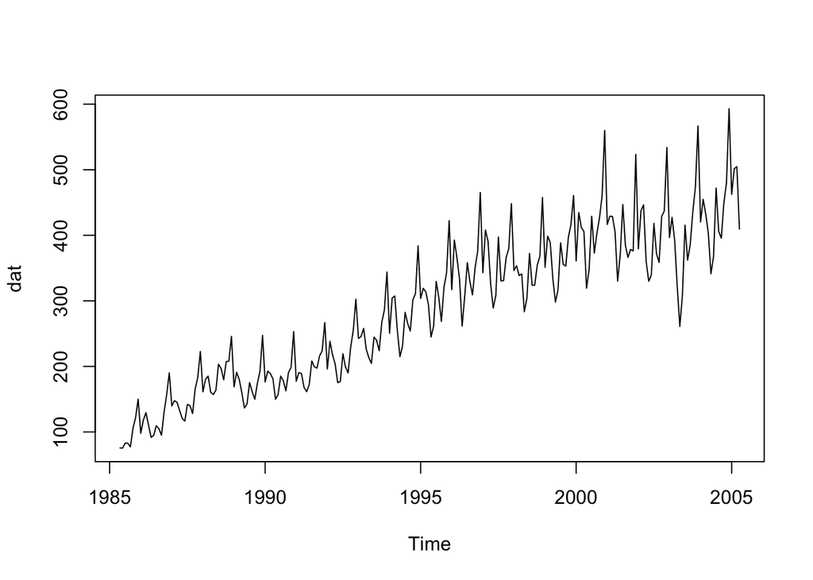

```r
dat <- visitors
plot(dat)
```

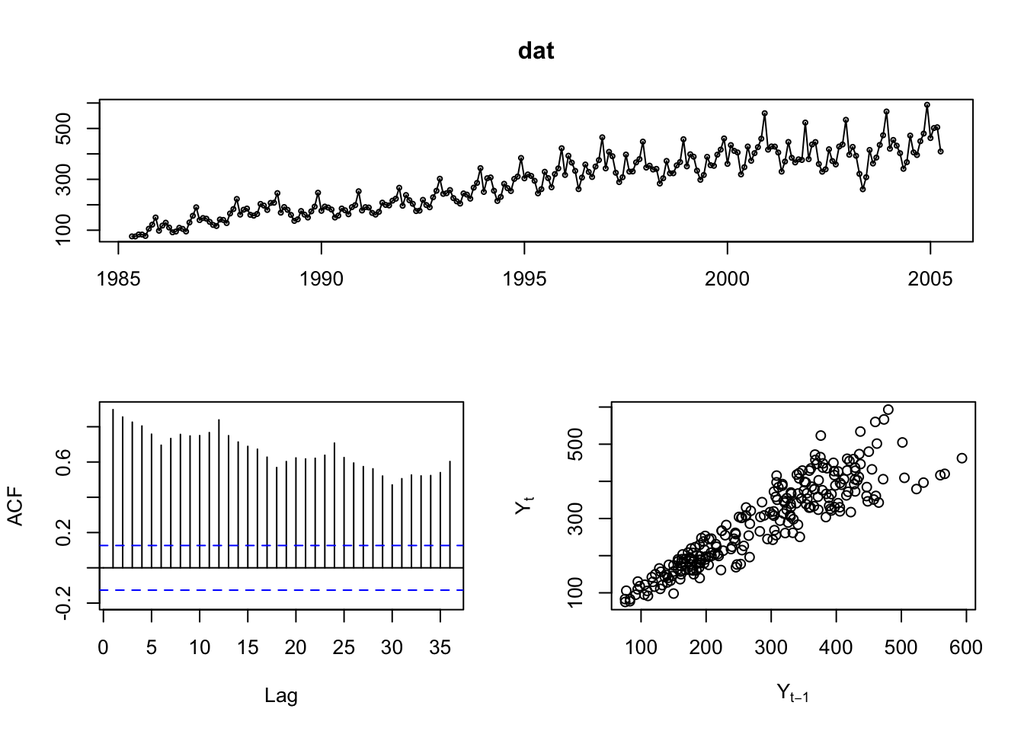

```r
tsdisplay(dat, plot.type="scatter")
```

- Iš pirmojo ir ACF grafikų galima matyti, jog duomenys yra sezoniški, bei turi didėjanti trendą, tačiau jis silpsta.
2. Prognozuojami du metai naudojantis Holt-Winters’ multiplikatyviu metodu:

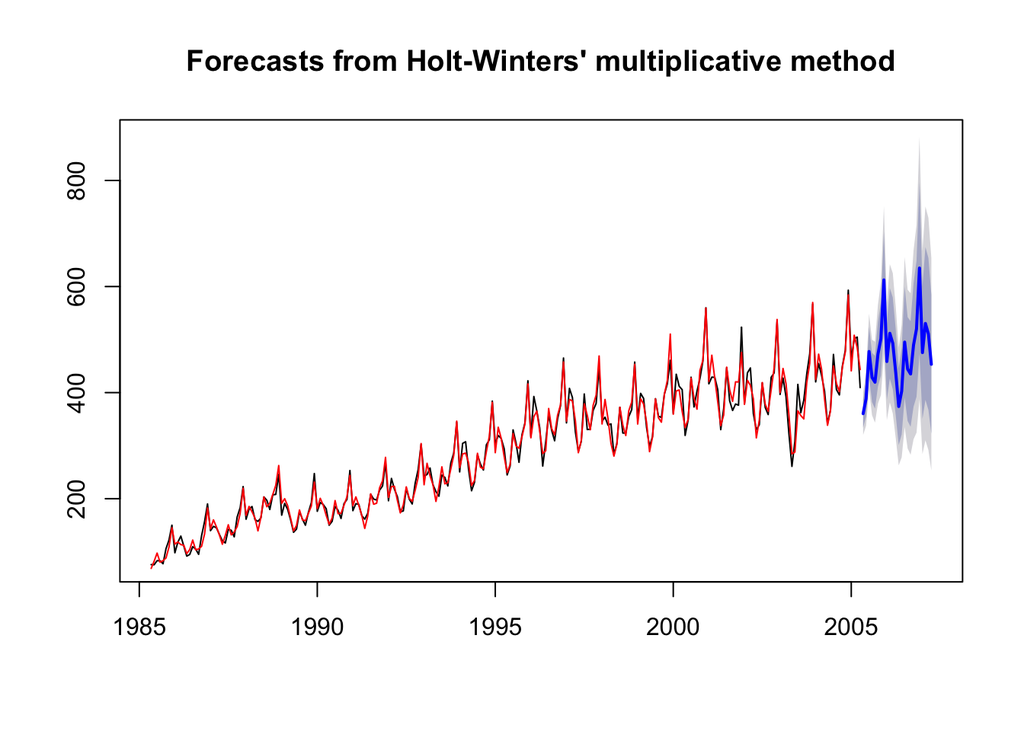

```r
frc <- hw(dat, seasonal="mult", h=24)
plot(frc)
lines(frc$fitted, col="red")
```

3. Būtinas, nes einant metams sezoniškumo įtaka vis didėja, o šis metodas į tai ir atsižvelgia.
4. Sukūriamos kelios prognozės su skirtingais trendais:

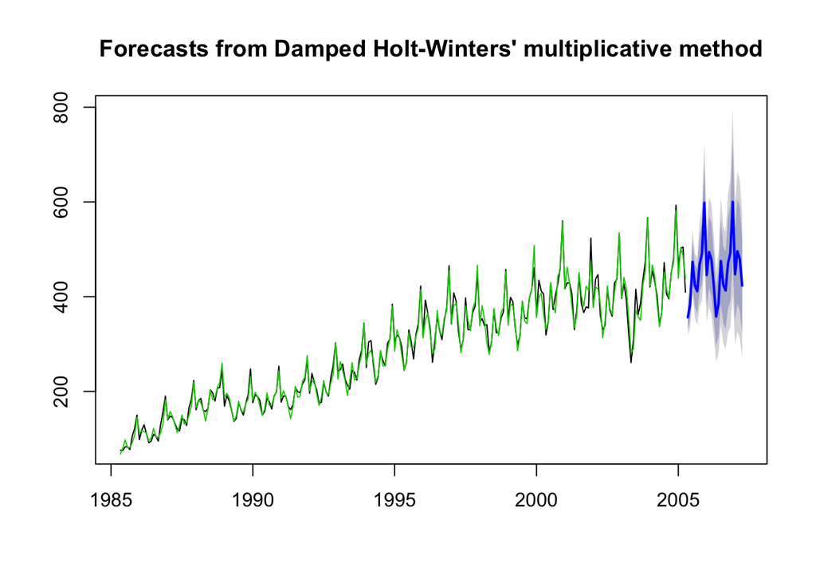

```r
frc2<-hw(dat, seasonal="mult", h=24, damped = TRUE)
plot(frc2)
lines(frc2$fitted, col=3)
```

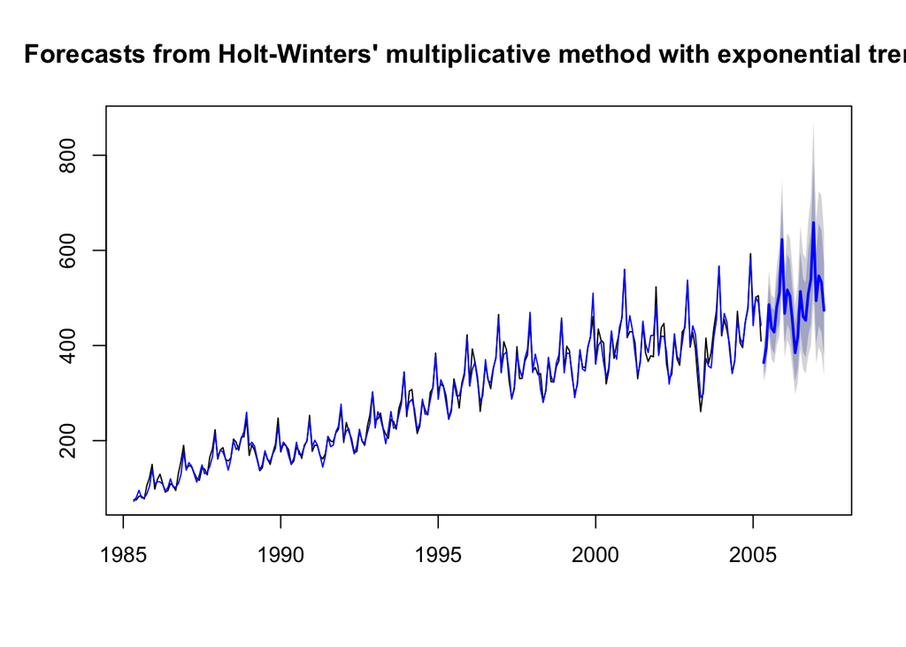

```r
frc3<-hw(dat, seasonal="mult", h=24, exponential=TRUE)
plot(frc3)
lines(frc3$fitted, col=4)
```

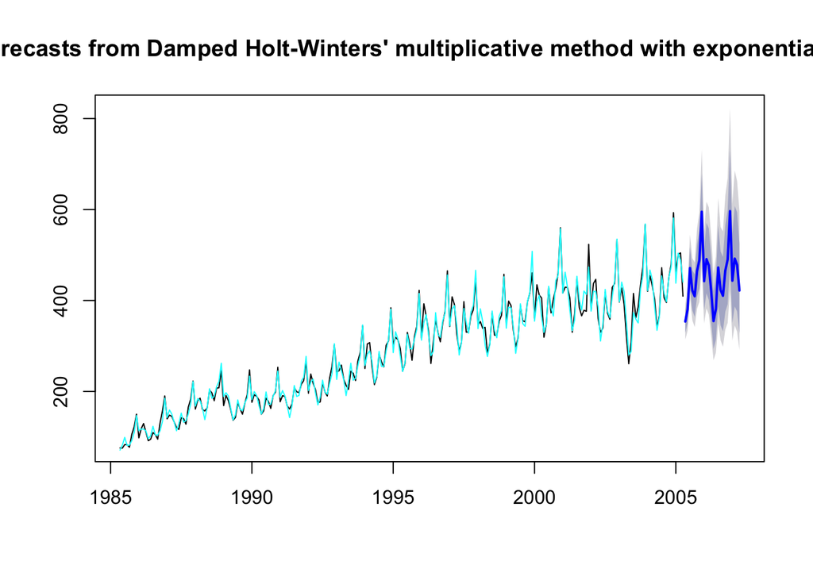

```r
frc4<-hw(dat, seasonal="mult", h=24, damped = TRUE, exponential=TRUE)
plot(frc4)
lines(frc4$fitted, col=5)
```

- Šiuo atveju labiausiai tinkami atrodo frc2 bei frc4 metodai, nes iš pradinių duomenų panašu, jog trendas yra mažėjantis, o šios prognozės ir slopina jį.
5. Ieškomas geriausias modelis (RMSE mažiausias):

```r
accuracy(frc)
```

```
##                      ME     RMSE      MAE       MPE     MAPE      MASE
## Training set -0.1452509 14.97355 11.07013 -0.272776 4.260436 0.4088095
##                    ACF1
## Training set 0.02049338
```

```r
accuracy(frc2)
```

```
##                    ME     RMSE      MAE       MPE     MAPE      MASE
## Training set 1.488349 14.44328 10.59863 0.3456988 4.023734 0.3913973
##                     ACF1
## Training set 0.001247452
```

```r
accuracy(frc3)
```

```
##                     ME     RMSE     MAE       MPE     MAPE      MASE
## Training set 0.4682805 14.49889 10.7262 0.1607469 4.089073 0.3961084
##                    ACF1
## Training set 0.08020814
```

```r
accuracy(frc4)
```

```
##                     ME     RMSE      MAE         MPE     MAPE     MASE
## Training set 0.6269735 14.42706 10.71517 -0.08278323 4.094691 0.395701
##                     ACF1
## Training set -0.01130712
```

- Galime matyti, jog ketvirtojo modelio RMSE mažiausias, tai jis yra geriausias iš pateiktų.
6. Tikrinamos liekanos, ar panašios į baltajį triukšmą:

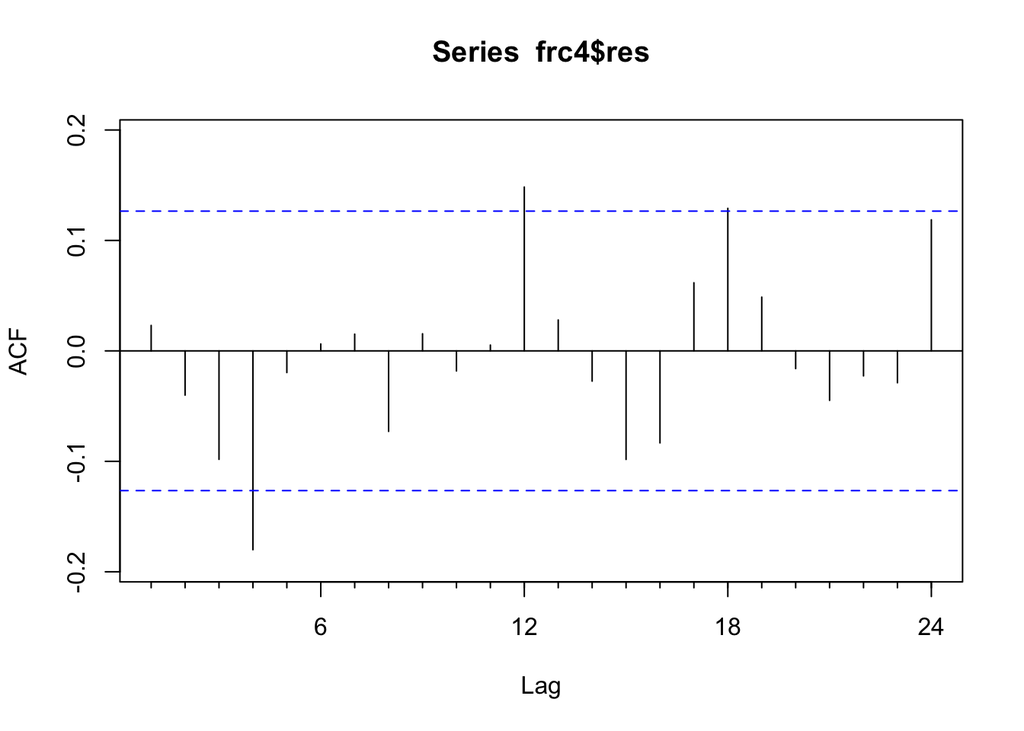

```r
Acf(frc4$res)
```

```r
Box.test(frc4$res, fitdf=0, type="Lj")
```

```
##
##  Box-Ljung test
##
## data:  frc4$res
## X-squared = 0.12908, df = 1, p-value = 0.7194
```

```r
#H0: liekanos yra baltasis triukšmas
#H1: liekanos nėra baltasis triukšmas
```

- Iš ACF grafiko galima matyti, jog tik trys reikšmės rodo reikšmingą autokoreliacija ir labai nežymiai kerta mėlyną punktyrą.
- p-value > 0.05, H0 priimama. Liekanos yra baltasis triukšmas (liekanos nekoreliuoja).

> Taigi galima būtų daryti išvada, jog šis modelis yra gana geras, t.y. prognozė su damped bei eksponentiniu trendu geriausiai prognozuoja iš sudarytų modelių.